# MPDW 1

Salsabila Dwi Rahmi

2023-09-04

```r
knitr::opts_chunk$set(echo = TRUE)
```

Persiapan library

```r
library("forecast")
```

```r
library("graphics")
library("TTR")
library("TSA")
library("rio")
```

Import Data

```r
library(rio)
data <- import("https://raw.githubusercontent.com/salsabiladwi/PRAKMPDW/main/Data/data1.csv")
```

Membuat set data menjadi data time series

```r
data.ts <- ts(data$Close)
data.ts
```

```
## Time Series:
## Start = 1
## End = 139
## Frequency = 1
##   [1] 2600 3180 3090 2380 2400 2870 2780 2960 2520 2230 2290 2180 2240 2470 2320
##  [16] 2350 2510 2620 2670 2420 2390 2520 2420 2330 2250 2230 2550 2610 2570 2590
##  [31] 2370 2400 2270 2270 2320 2440 2410 2290 2290 2330 2420 2450 2320 2380 2370
##  [46] 2330 2440 2340 2330 2290 2240 2250 2230 1965 1935 1765 1840 1880 1945 2220
##  [61] 2290 2570 2350 2640 2440 2760 2780 2790 2600 2600 2330 2460 2490 2510 2400
##  [76] 2150 1965 1800 1720 1650 1675 2000 1970 2240 2050 1995 1935 1920 2070 2080
##  [91] 1920 1930 1830 1820 1840 1830 2000 1975 1970 2040 1990 1935 2030 2010 1965
## [106] 2130 2270 2320 2350 2220 2110 2030 2010 1875 1795 1885 2090 2100 2130 2100
## [121] 2080 2130 2040 1935 1945 1895 1985 2040 2010 1950 2020 1990 1990 1970 2010
## [136] 1990 1960 1995 1990
```

```r
summary(data.ts)
```

```
##    Min. 1st Qu.  Median    Mean 3rd Qu.    Max.
##    1650    1990    2230    2220    2400    3180
```

Membuat plot time series

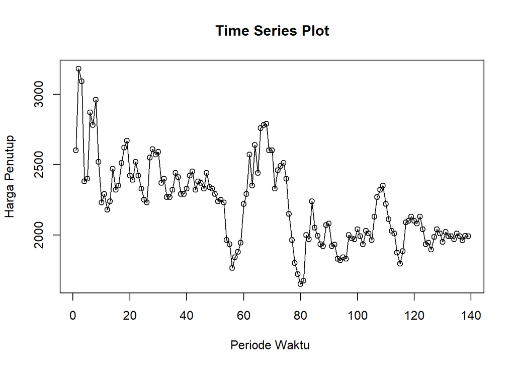

```r
ts.plot(data.ts, xlab="Periode Waktu ", ylab="Harga Penutup", main = "Time Series Plot")
points(data.ts)
```

Pembagian data latih dan data uji dilakukan dengan perbandingan 80% data latih dan 20% data uji.

```r
#membagi data latih dan data uji
training_data <- data[1:111,]
testing_data <- data[112:139,]
train_data.ts <- ts(training_data$Close)
test_data.ts <- ts(testing_data$Close)
```

Eksplorasi Data

Eksplorasi data dilakukan pada keseluruhan data, data latih serta data uji menggunakan plot data deret waktu.

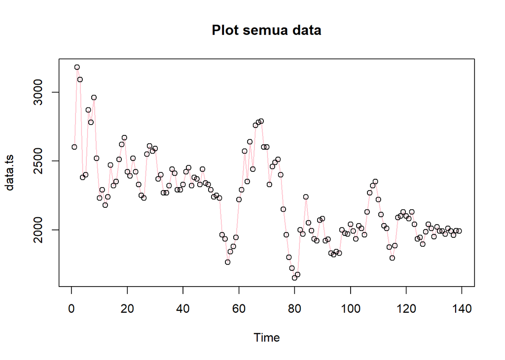

```r
#eksplorasi keseluruhan data
plot(data.ts, col="pink",main="Plot semua data")
points(data.ts)
```

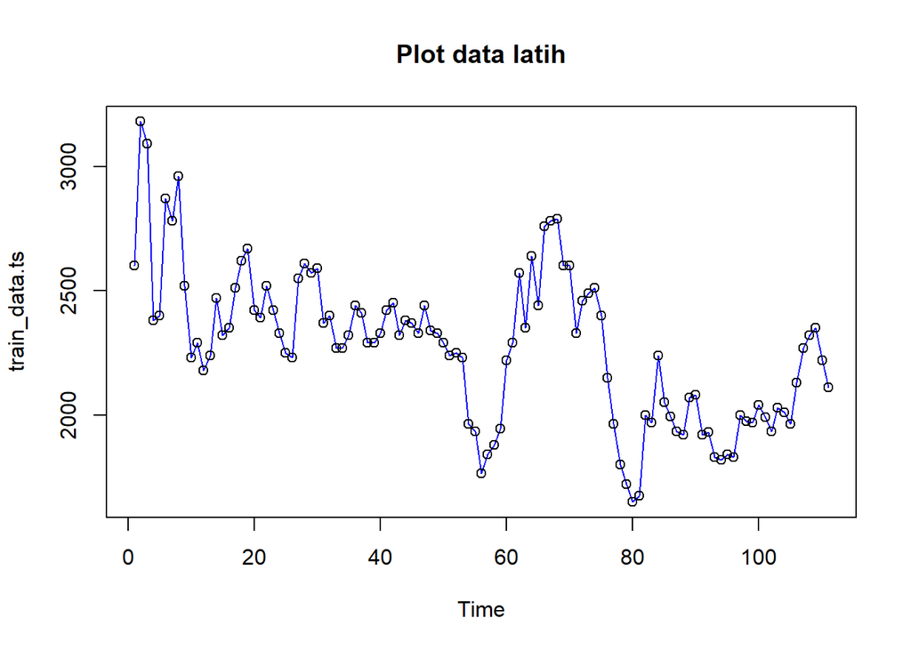

```r
#eksplorasi data latih
plot(train_data.ts, col="blue",main="Plot data latih")
points(train_data.ts)
```

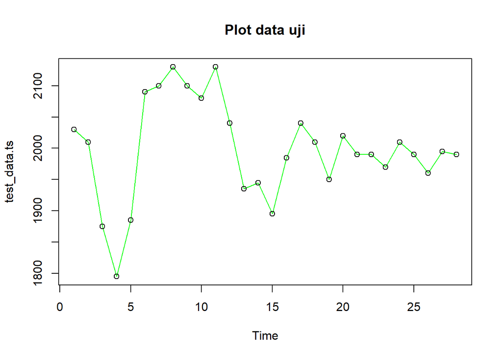

```r
#eksplorasi data uji
plot(test_data.ts, col="green",main="Plot data uji")
points(test_data.ts)
```

Eksplorasi data juga dapat dilakukan menggunakan package ggplot2 dengan terlebih dahulu memanggil library package ggplot2.

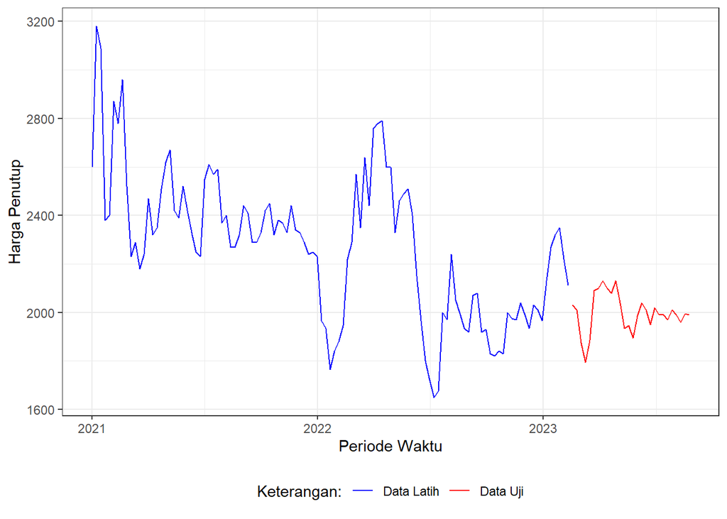

```r
#Eksplorasi dengan GGPLOT
library(ggplot2)
ggplot() +
  geom_line(data = training_data, aes(x = Date, y = Close, col = "Data Latih")) +
  geom_line(data = testing_data, aes(x = Date, y = Close, col = "Data Uji")) +
  labs(x = "Periode Waktu", y = "Harga Penutup", color = "Legend") +
  scale_colour_manual(name="Keterangan:", breaks = c("Data Latih", "Data Uji"),
                      values = c("blue", "red")) +
  theme_bw() + theme(legend.position = "bottom",
                     plot.caption = element_text(hjust=0.5, size=12))
```

Plot menunjukkan pola data konstan baik untuk data uji maupun data latih

### Single Moving Average (SMA)

Pola data yang dihasilkan dari set data Saham Antam Harian adalah konstan.

Metode pemulusan SMA cocok digunakan untuk pola data stasioner atau konstan.Set data saham ANTAM yang saya gunakan juga merupakan daya yang konstan. Prinsip dasar metode pemulusan ini adalah data pemulusan pada periode ke-t merupakan rata rata dari m buah data pada periode ke-t hingga periode ke (t-m+1). Data pemulusan pada periode ke-t selanjutnya digunakan sebagai nilai peramalan pada periode ke t+1

Pemulusan menggunakan metode SMA dilakukan dengan fungsi `SMA()`. Dalam hal ini akan dilakukan pemulusan dengan parameter `m=2`.

```r
data.sma<-SMA(train_data.ts, n=2)
data.sma
```

```
## Time Series:
## Start = 1
## End = 111
## Frequency = 1
##   [1]     NA 2890.0 3135.0 2735.0 2390.0 2635.0 2825.0 2870.0 2740.0 2375.0
##  [11] 2260.0 2235.0 2210.0 2355.0 2395.0 2335.0 2430.0 2565.0 2645.0 2545.0
##  [21] 2405.0 2455.0 2470.0 2375.0 2290.0 2240.0 2390.0 2580.0 2590.0 2580.0
##  [31] 2480.0 2385.0 2335.0 2270.0 2295.0 2380.0 2425.0 2350.0 2290.0 2310.0
##  [41] 2375.0 2435.0 2385.0 2350.0 2375.0 2350.0 2385.0 2390.0 2335.0 2310.0
##  [51] 2265.0 2245.0 2240.0 2097.5 1950.0 1850.0 1802.5 1860.0 1912.5 2082.5
##  [61] 2255.0 2430.0 2460.0 2495.0 2540.0 2600.0 2770.0 2785.0 2695.0 2600.0
##  [71] 2465.0 2395.0 2475.0 2500.0 2455.0 2275.0 2057.5 1882.5 1760.0 1685.0
##  [81] 1662.5 1837.5 1985.0 2105.0 2145.0 2022.5 1965.0 1927.5 1995.0 2075.0
##  [91] 2000.0 1925.0 1880.0 1825.0 1830.0 1835.0 1915.0 1987.5 1972.5 2005.0
## [101] 2015.0 1962.5 1982.5 2020.0 1987.5 2047.5 2200.0 2295.0 2335.0 2285.0
## [111] 2165.0
```

Data pemulusan pada periode ke-t selanjutnya digunakan sebagai nilai peramalan pada periode ke t+1 sehingga hasil peramalan 1 periode kedepan adalah sebagai berikut.

```r
data.ramal<-c(NA,data.sma)
data.ramal #forecast 1 periode ke depan
```

```
##   [1]     NA     NA 2890.0 3135.0 2735.0 2390.0 2635.0 2825.0 2870.0 2740.0
##  [11] 2375.0 2260.0 2235.0 2210.0 2355.0 2395.0 2335.0 2430.0 2565.0 2645.0
##  [21] 2545.0 2405.0 2455.0 2470.0 2375.0 2290.0 2240.0 2390.0 2580.0 2590.0
##  [31] 2580.0 2480.0 2385.0 2335.0 2270.0 2295.0 2380.0 2425.0 2350.0 2290.0
##  [41] 2310.0 2375.0 2435.0 2385.0 2350.0 2375.0 2350.0 2385.0 2390.0 2335.0
##  [51] 2310.0 2265.0 2245.0 2240.0 2097.5 1950.0 1850.0 1802.5 1860.0 1912.5
##  [61] 2082.5 2255.0 2430.0 2460.0 2495.0 2540.0 2600.0 2770.0 2785.0 2695.0
##  [71] 2600.0 2465.0 2395.0 2475.0 2500.0 2455.0 2275.0 2057.5 1882.5 1760.0
##  [81] 1685.0 1662.5 1837.5 1985.0 2105.0 2145.0 2022.5 1965.0 1927.5 1995.0
##  [91] 2075.0 2000.0 1925.0 1880.0 1825.0 1830.0 1835.0 1915.0 1987.5 1972.5
## [101] 2005.0 2015.0 1962.5 1982.5 2020.0 1987.5 2047.5 2200.0 2295.0 2335.0
## [111] 2285.0 2165.0
```

Selanjutnya akan dilakukan peramalan sejumlah data uji yaitu 28 periode. Pada metode SMA, hasil peramalan 28 periode ke depan akan bernilai sama dengan hasil peramalan 1 periode kedepan. Dalam hal ini akan dilakukan pengguabungan data aktual train, data hasil pemulusan dan data hasil ramalan 28 periode kedepan.

```r
data.gab<-cbind(aktual=c(train_data.ts,rep(NA,28)),pemulusan=c(data.sma,rep(NA,28)),ramalan=c(data.ramal,rep(data.ramal[length(data.ramal)],27)))
data.gab #forecast 24 periode ke depan
```

```
##        aktual pemulusan ramalan
##   [1,]   2600        NA      NA
##   [2,]   3180    2890.0      NA
##   [3,]   3090    3135.0  2890.0
##   [4,]   2380    2735.0  3135.0
##   [5,]   2400    2390.0  2735.0
##   [6,]   2870    2635.0  2390.0
##   [7,]   2780    2825.0  2635.0
##   [8,]   2960    2870.0  2825.0
##   [9,]   2520    2740.0  2870.0
##  [10,]   2230    2375.0  2740.0
##  [11,]   2290    2260.0  2375.0
##  [12,]   2180    2235.0  2260.0
##  [13,]   2240    2210.0  2235.0
##  [14,]   2470    2355.0  2210.0
```

[output cut: 125 more lines]

Adapun plot data deret waktu dari hasil peramalan yang dilakukan adalah sebagai berikut.

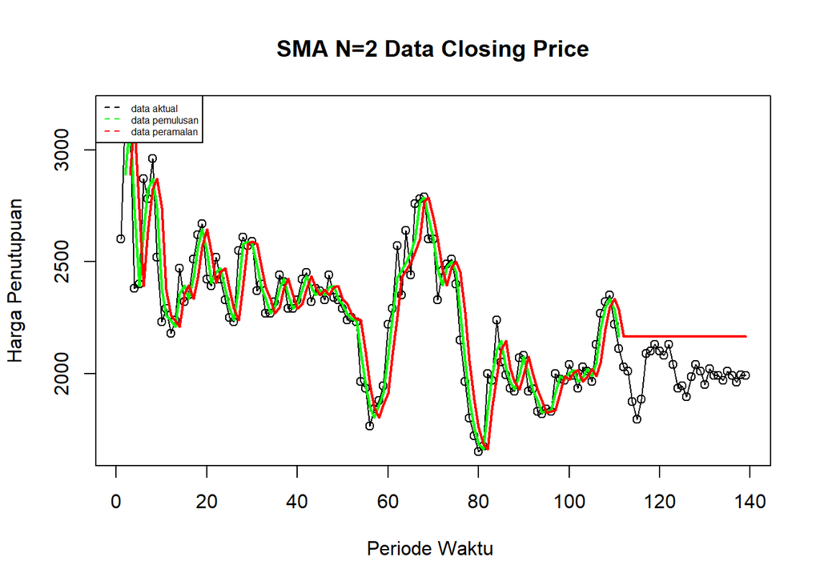

```r
ts.plot(data.ts, xlab="Periode Waktu ", ylab="Harga Penutupuan", main= "SMA N=2 Data Closing Price")
points(data.ts)
lines(data.gab[,2],col="green",lwd=2)
lines(data.gab[,3],col="red",lwd=2)
legend("topleft",c("data aktual","data pemulusan","data peramalan"), lty=8, col=c("black","green","red"), cex=0.5)
```

Selanjutnya perhitungan akurasi dilakukan dengan ukuran akurasi *Sum Squares Error* (SSE), *Mean Square Error* (MSE) dan *Mean Absolute Percentage Error* (MAPE). Perhitungan akurasi dilakukan baik pada data latih maupun pada data uji.

```r
#Menghitung nilai keakuratan data latih
error_train.sma = train_data.ts-data.ramal[1:length(train_data.ts)]
SSE_train.sma = sum(error_train.sma[5:length(train_data.ts)]^2)
MSE_train.sma = mean(error_train.sma[5:length(train_data.ts)]^2)
MAPE_train.sma = mean(abs((error_train.sma[5:length(train_data.ts)]/train_data.ts[5:length(train_data.ts)])*100))

akurasi_train.sma <- matrix(c(SSE_train.sma, MSE_train.sma, MAPE_train.sma))
row.names(akurasi_train.sma)<- c("SSE", "MSE", "MAPE")
colnames(akurasi_train.sma) <- c("Akurasi m = 2")
akurasi_train.sma
```

```
##      Akurasi m = 2
## SSE   2.792200e+06
## MSE   2.609533e+04
## MAPE  5.521685e+00
```

Dalam hal ini nilai MAPE data latih pada metode pemulusan SMA kurang dari 6%, nilai ini dapat dikategorikan sebagai nilai akurasi yang sangat baik. Selanjutnya dilakukan perhitungan nilai MAPE data uji pada metde pemulusan SMA.

```r
#Menghitung nilai keakuratan data uji
error_test.sma = test_data.ts-data.gab[112:139,3]
SSE_test.sma = sum(error_test.sma^2)
MSE_test.sma = mean(error_test.sma^2)
MAPE_test.sma = mean(abs((error_test.sma/test_data.ts*100)))

akurasi_test.sma <- matrix(c(SSE_test.sma, MSE_test.sma, MAPE_test.sma))
row.names(akurasi_test.sma)<- c("SSE", "MSE", "MAPE")
colnames(akurasi_test.sma) <- c("Akurasi m = 2")
akurasi_test.sma
```

```
##      Akurasi m = 2
## SSE   9.500000e+05
## MSE   3.392857e+04
## MAPE  8.532038e+00
```

DPerhitungan akurasi menggunakan data latih menghasilkan nilai MAPE yang kurang dari 10% sehingga nilai akurasi ini dapat dikategorikan sebagai sangat baik.

Single Exponential Smoothing

Metode Exponential Smoothing adalah metode pemulusan dengan melakukan pembobotan menurun secara eksponensial. Nilai yang lebih baru diberi bobot yang lebih besar dari nilai terdahulu. Terdapat satu atau lebih parameter pemulusan yang ditentukan secara eksplisit, dan hasil pemilihan parameter tersebut akan menentukan bobot yang akan diberikan pada nilai pengamatan. Ada dua macam model, yaitu model tunggal dan ganda.

SES

Single Exponential Smoothing merupakan metode pemulusan yang tepat digunakan untuk data dengan pola stasioner atau konstan.

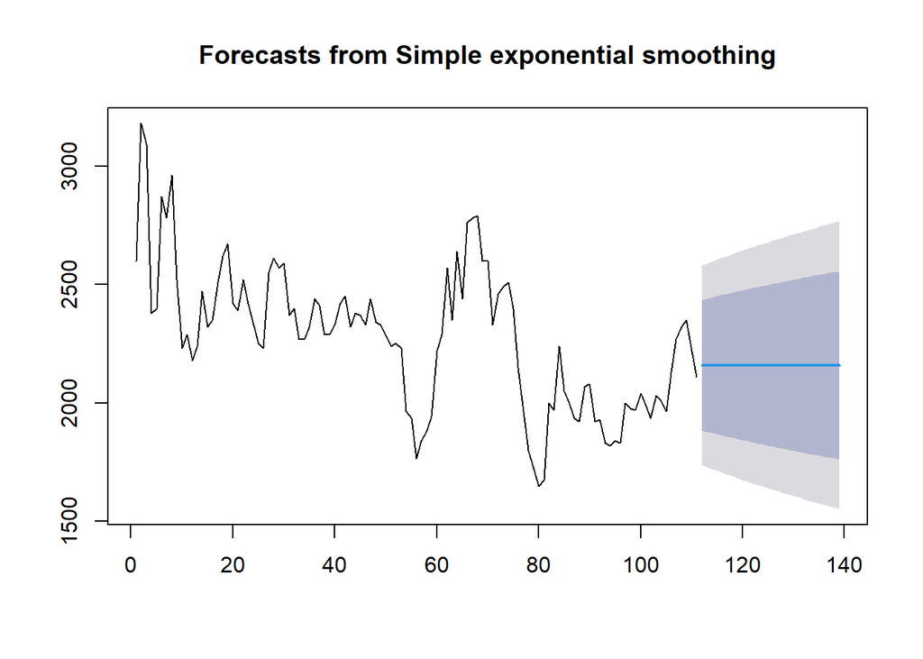

```r
#Cara 1 (fungsi ses)
ses.1 <- ses(train_data.ts, h = 28, alpha = 0.2)
plot(ses.1)
```

```r
ses.1
```

```
##     Point Forecast    Lo 80    Hi 80    Lo 95    Hi 95
## 112       2159.303 1884.155 2434.452 1738.500 2580.107
## 113       2159.303 1878.706 2439.901 1730.166 2588.440
## 114       2159.303 1873.361 2445.246 1721.992 2596.615
## 115       2159.303 1868.114 2450.493 1713.967 2604.640
## 116       2159.303 1862.959 2455.648 1706.084 2612.523
## 117       2159.303 1857.893 2460.714 1698.336 2620.270
## 118       2159.303 1852.911 2465.696 1690.717 2627.890
## 119       2159.303 1848.008 2470.599 1683.219 2635.388
## 120       2159.303 1843.182 2475.425 1675.837 2642.770
## 121       2159.303 1838.428 2480.179 1668.567 2650.040
## 122       2159.303 1833.743 2484.864 1661.402 2657.205
## 123       2159.303 1829.125 2489.482 1654.339 2664.268
## 124       2159.303 1824.571 2494.036 1647.374 2671.233
## 125       2159.303 1820.078 2498.529 1640.502 2678.105
## 126       2159.303 1815.643 2502.964 1633.720 2684.887
## 127       2159.303 1811.265 2507.342 1627.025 2691.582
## 128       2159.303 1806.941 2511.666 1620.412 2698.195
## 129       2159.303 1802.670 2515.937 1613.880 2704.727
## 130       2159.303 1798.449 2520.157 1607.425 2711.182
## 131       2159.303 1794.278 2524.329 1601.045 2717.562
## 132       2159.303 1790.153 2528.454 1594.736 2723.870
## 133       2159.303 1786.074 2532.533 1588.498 2730.109
## 134       2159.303 1782.039 2536.568 1582.327 2736.280
## 135       2159.303 1778.046 2540.560 1576.221 2742.386
## 136       2159.303 1774.095 2544.511 1570.179 2748.428
## 137       2159.303 1770.185 2548.422 1564.198 2754.409
## 138       2159.303 1766.313 2552.294 1558.276 2760.331
## 139       2159.303 1762.479 2556.128 1552.412 2766.195
```

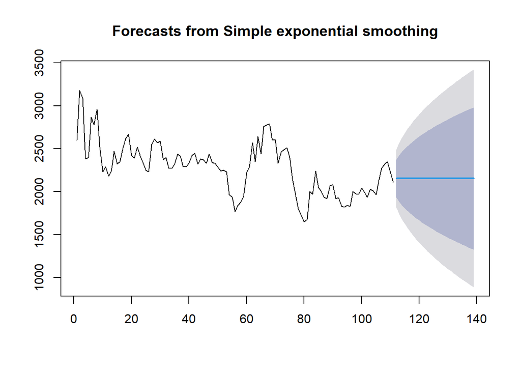

```r
ses.2<- ses(train_data.ts, h = 28, alpha = 0.7)
plot(ses.2)
```

```r
ses.2
```

```
##     Point Forecast    Lo 80    Hi 80     Lo 95    Hi 95
## 112       2153.034 1933.109 2372.960 1816.6870 2489.381
## 113       2153.034 1884.581 2421.488 1742.4701 2563.598
## 114       2153.034 1843.571 2462.497 1679.7517 2626.317
## 115       2153.034 1807.394 2498.674 1624.4230 2681.645
## 116       2153.034 1774.660 2531.409 1574.3606 2731.708
## 117       2153.034 1744.540 2561.528 1528.2970 2777.771
## 118       2153.034 1716.494 2589.574 1485.4040 2820.664
## 119       2153.034 1690.144 2615.924 1445.1052 2860.963
## 120       2153.034 1665.216 2640.853 1406.9800 2899.088
## 121       2153.034 1641.500 2664.568 1370.7105 2935.358
## 122       2153.034 1618.837 2687.232 1336.0496 2970.019
## 123       2153.034 1597.096 2708.972 1302.8006 3003.268
## 124       2153.034 1576.175 2729.894 1270.8037 3035.265
## 125       2153.034 1555.986 2750.083 1239.9274 3066.141
## 126       2153.034 1536.457 2769.611 1210.0615 3096.007
## 127       2153.034 1517.529 2788.539 1181.1129 3124.955
## 128       2153.034 1499.148 2806.920 1153.0020 3153.066
## 129       2153.034 1481.270 2824.798 1125.6600 3180.408
## 130       2153.034 1463.856 2842.212 1099.0270 3207.041
## 131       2153.034 1446.871 2859.197 1073.0506 3233.018
## 132       2153.034 1430.285 2875.784 1047.6845 3258.384
## 133       2153.034 1414.071 2891.997 1022.8875 3283.181
## 134       2153.034 1398.205 2907.863  998.6231 3307.445
## 135       2153.034 1382.666 2923.402  974.8583 3331.210
## 136       2153.034 1367.435 2938.634  951.5635 3354.505
## 137       2153.034 1352.493 2953.576  928.7118 3377.356
## 138       2153.034 1337.825 2968.244  906.2790 3399.789
## 139       2153.034 1323.416 2982.652  884.2426 3421.826
```

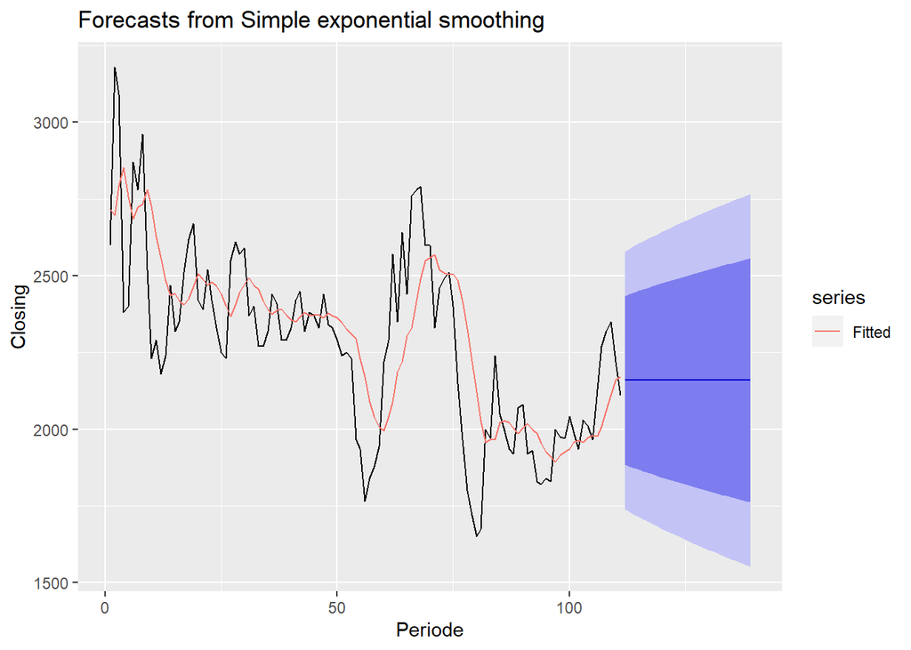

```r
autoplot(ses.1) +
  autolayer(fitted(ses.1), series="Fitted") +
  ylab("Closing") + xlab("Periode")
```

Pada fungsi ses() , terdapat beberapa argumen yang umum digunakan, yaitu nilia y , gamma , beta , alpha , dan h .

Nilai y adalah nilai data deret waktu, gamma adalah parameter pemulusan untuk komponen musiman, beta adalah parameter pemulusan untuk tren, dan alpha adalah parameter pemulusan untuk stasioner, serta h adalah banyaknya periode yang akan diramalkan.

Kasus di atas merupakan contoh inisialisasi nilai parameter $\lambda$ dengan nilai alpha 0,2 dan 0,7 dan banyak periode data yang akan diramalkan adalah sebanyak 28 periode. Selanjutnya akan digunakan fungsi HoltWinters() dengan nilai inisialisasi parameter dan panjang periode peramalan yang sama dengan fungsi ses() .

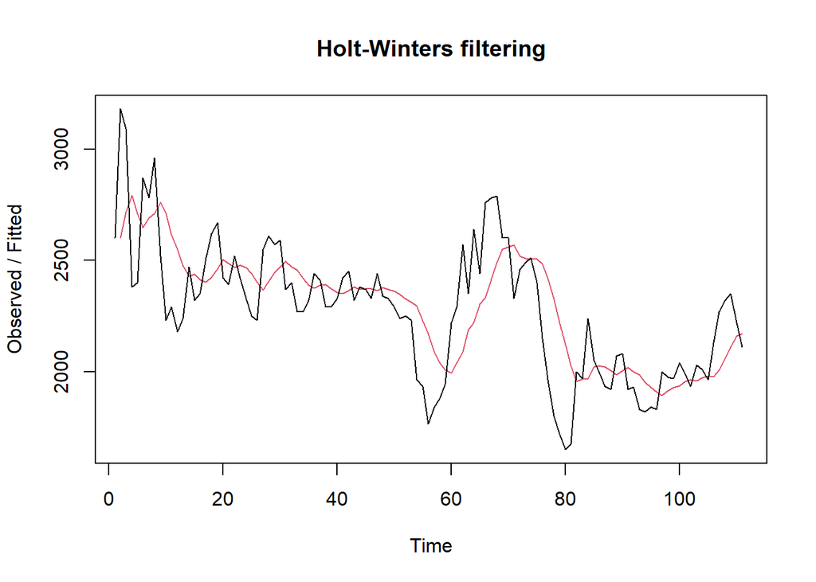

```r
#Cara 2 (fungsi Holtwinter)
ses1<- HoltWinters(train_data.ts, gamma = FALSE, beta = FALSE, alpha = 0.2)
plot(ses1)
```

```r
#ramalan
ramalan1<- forecast(ses1, h=28)
ramalan1
```

```
##     Point Forecast    Lo 80    Hi 80    Lo 95    Hi 95
## 112       2159.303 1884.288 2434.318 1738.704 2579.903
## 113       2159.303 1878.842 2439.765 1730.375 2588.232
## 114       2159.303 1873.500 2445.107 1722.204 2596.403
## 115       2159.303 1868.255 2450.352 1714.183 2604.424
## 116       2159.303 1863.103 2455.504 1706.304 2612.303
## 117       2159.303 1858.040 2460.567 1698.560 2620.047
## 118       2159.303 1853.060 2465.547 1690.944 2627.663
## 119       2159.303 1848.160 2470.447 1683.450 2635.157
## 120       2159.303 1843.335 2475.272 1676.072 2642.535
## 121       2159.303 1838.584 2480.023 1668.805 2649.802
## 122       2159.303 1833.901 2484.706 1661.644 2656.963
## 123       2159.303 1829.285 2489.321 1654.585 2664.022
## 124       2159.303 1824.733 2493.874 1647.623 2670.984
## 125       2159.303 1820.242 2498.365 1640.754 2677.853
## 126       2159.303 1815.810 2502.797 1633.975 2684.632
## 127       2159.303 1811.434 2507.173 1627.283 2691.324
## 128       2159.303 1807.112 2511.494 1620.674 2697.933
## 129       2159.303 1802.843 2515.764 1614.145 2704.462
## 130       2159.303 1798.625 2519.982 1607.693 2710.914
## 131       2159.303 1794.455 2524.152 1601.316 2717.291
## 132       2159.303 1790.332 2528.275 1595.011 2723.596
## 133       2159.303 1786.255 2532.352 1588.775 2729.832
## 134       2159.303 1782.222 2536.385 1582.607 2736.000
## 135       2159.303 1778.232 2540.375 1576.504 2742.103
## 136       2159.303 1774.282 2544.324 1570.465 2748.142
## 137       2159.303 1770.374 2548.233 1564.487 2754.120
## 138       2159.303 1766.504 2552.103 1558.568 2760.039
## 139       2159.303 1762.671 2555.936 1552.707 2765.900
```

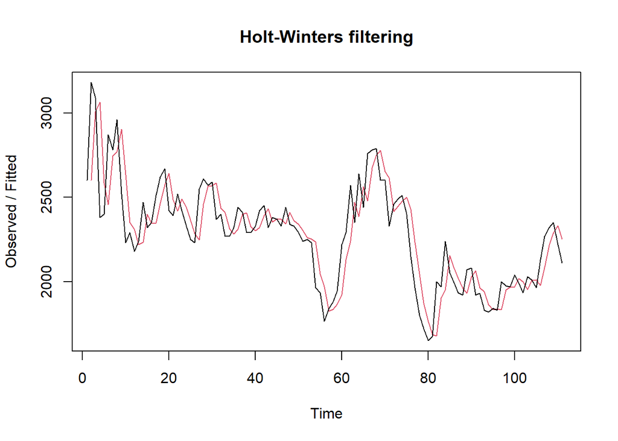

```r
ses2<- HoltWinters(train_data.ts, gamma = FALSE, beta = FALSE, alpha = 0.7)
plot(ses2)
```

```r
#ramalan
ramalan2<- forecast(ses2, h=28)
ramalan2
```

```
##     Point Forecast    Lo 80    Hi 80     Lo 95    Hi 95
## 112       2153.034 1932.412 2373.656 1815.6222 2490.446
## 113       2153.034 1883.731 2422.337 1741.1704 2564.898
## 114       2153.034 1842.592 2463.477 1678.2535 2627.815
## 115       2153.034 1806.300 2499.769 1622.7497 2683.319
## 116       2153.034 1773.462 2532.606 1572.5287 2733.540
## 117       2153.034 1743.247 2562.821 1526.3193 2779.749
## 118       2153.034 1715.112 2590.956 1483.2906 2822.778
## 119       2153.034 1688.679 2617.389 1442.8642 2863.204
## 120       2153.034 1663.671 2642.397 1404.6183 2901.450
## 121       2153.034 1639.881 2666.187 1368.2340 2937.834
## 122       2153.034 1617.146 2688.923 1333.4634 2972.605
## 123       2153.034 1595.336 2710.732 1300.1091 3005.959
## 124       2153.034 1574.349 2731.720 1268.0109 3038.057
## 125       2153.034 1554.096 2751.973 1237.0369 3069.031
## 126       2153.034 1534.506 2771.563 1207.0765 3098.992
## 127       2153.034 1515.517 2790.551 1178.0363 3128.032
## 128       2153.034 1497.078 2808.990 1149.8363 3156.232
## 129       2153.034 1479.144 2826.925 1122.4077 3183.661
## 130       2153.034 1461.674 2844.394 1095.6904 3210.378
## 131       2153.034 1444.635 2861.433 1069.6318 3236.437
## 132       2153.034 1427.997 2878.071 1044.1854 3261.883
## 133       2153.034 1411.732 2894.337 1019.3100 3286.758
## 134       2153.034 1395.816 2910.252  994.9687 3311.100
## 135       2153.034 1380.228 2925.841  971.1287 3334.940
## 136       2153.034 1364.948 2941.120  947.7602 3358.308
## 137       2153.034 1349.959 2956.110  924.8362 3381.232
## 138       2153.034 1335.244 2970.824  902.3322 3403.736
## 139       2153.034 1320.790 2985.279  880.2262 3425.842
```

Fungsi HoltWinters memiliki argumen yang sama dengan fungsi ses() . Argumen-argumen kedua fungsi dapat dilihat lebih lanjut dengan ?ses() atau ?HoltWinters .

Nilai parameter $\alpha$ dari kedua fungsi dapat dioptimalkan menyesuaikan dari error-nya paling minimumnya. Caranya adalah dengan membuat parameter $\alpha =$ NULL .

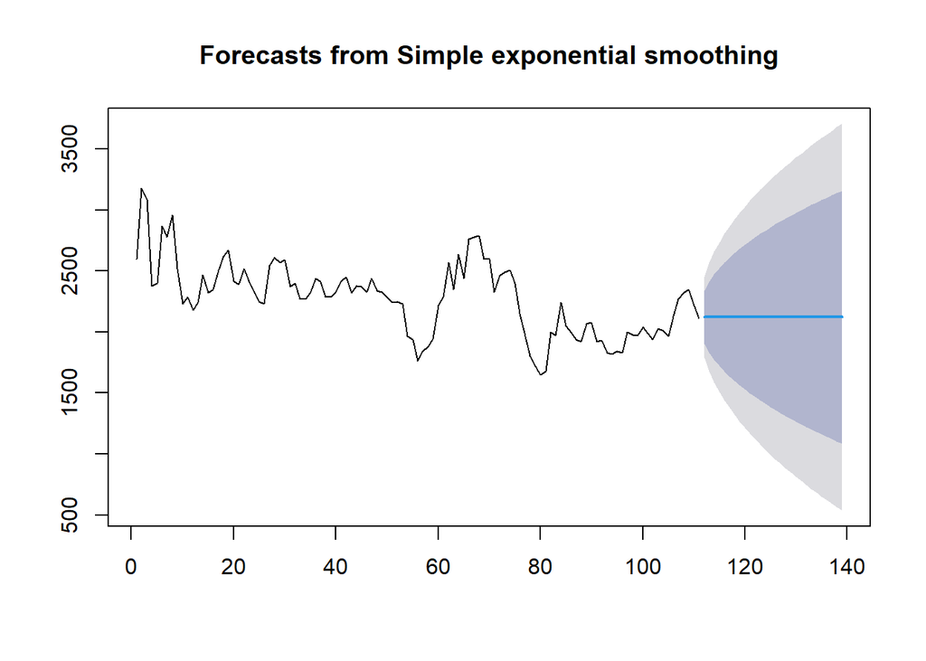

```r
#SES
ses.opt <- ses(train_data.ts, h = 28, alpha = NULL)
plot(ses.opt)
```

```r
ses.opt
```

```
##     Point Forecast    Lo 80    Hi 80     Lo 95    Hi 95
## 112        2122.21 1905.426 2338.993 1790.6683 2453.751
## 113        2122.21 1830.500 2413.919 1676.0778 2568.341
## 114        2122.21 1771.219 2473.200 1585.4158 2659.003
## 115        2122.21 1720.595 2523.824 1507.9934 2736.426
## 116        2122.21 1675.674 2568.745 1439.2926 2805.127
## 117        2122.21 1634.876 2609.543 1376.8979 2867.521
## 118        2122.21 1597.240 2647.179 1319.3375 2925.082
## 119        2122.21 1562.127 2682.293 1265.6365 2978.783
## 120        2122.21 1529.088 2715.331 1215.1090 3029.310
## 121        2122.21 1497.796 2746.623 1167.2512 3077.168
## 122        2122.21 1467.998 2776.421 1121.6800 3122.739
## 123        2122.21 1439.500 2804.919 1078.0959 3166.323
## 124        2122.21 1412.145 2832.274 1036.2596 3208.160
## 125        2122.21 1385.805 2858.614  995.9763 3248.443
## 126        2122.21 1360.376 2884.044  957.0850 3287.334
## 127        2122.21 1335.768 2908.651  919.4505 3324.969
## 128        2122.21 1311.907 2932.512  882.9585 3361.461
## 129        2122.21 1288.729 2955.690  847.5107 3396.908
## 130        2122.21 1266.178 2978.241  813.0223 3431.397
## 131        2122.21 1244.206 3000.213  779.4195 3465.000
## 132        2122.21 1222.771 3021.648  746.6373 3497.782
## 133        2122.21 1201.835 3042.584  714.6183 3529.801
## 134        2122.21 1181.365 3063.054  683.3117 3561.107
## 135        2122.21 1161.331 3083.089  652.6718 3591.747
## 136        2122.21 1141.705 3102.714  622.6579 3621.761
## 137        2122.21 1122.466 3121.954  593.2331 3651.186
## 138        2122.21 1103.589 3140.830  564.3639 3680.055
## 139        2122.21 1085.056 3159.363  536.0201 3708.399
```

```r
#Lamda Optimum Holt Winter
sesopt<- HoltWinters(train_data.ts, gamma = FALSE, beta = FALSE,alpha = NULL)
sesopt
```

```
## Holt-Winters exponential smoothing without trend and without seasonal component.
##
## Call:
## HoltWinters(x = train_data.ts, alpha = NULL, beta = FALSE, gamma = FALSE)
##
## Smoothing parameters:
##  alpha: 0.9291784
##  beta : FALSE
##  gamma: FALSE
##
## Coefficients:
##      [,1]
## a 2118.43
```

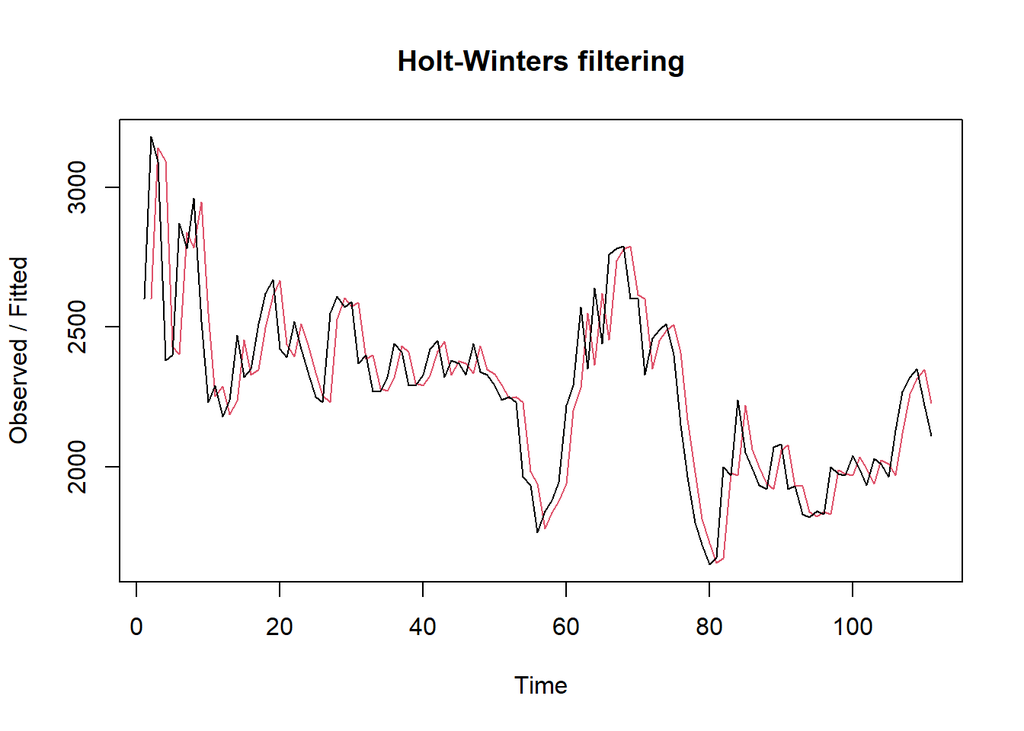

```r
plot(sesopt)
```

```r
#ramalan
ramalanopt<- forecast(sesopt, h=28)
ramalanopt
```

```
##     Point Forecast    Lo 80    Hi 80     Lo 95    Hi 95
## 112        2118.43 1901.825 2335.035 1787.1617 2449.699
## 113        2118.43 1822.753 2414.108 1666.2307 2570.630
## 114        2118.43 1760.754 2476.107 1571.4111 2665.449
## 115        2118.43 1708.016 2528.845 1490.7556 2746.105
## 116        2118.43 1661.323 2575.538 1419.3444 2817.516
## 117        2118.43 1618.976 2617.885 1354.5804 2882.280
## 118        2118.43 1579.949 2656.912 1294.8939 2941.967
## 119        2118.43 1543.565 2693.295 1239.2502 2997.610
## 120        2118.43 1509.351 2727.509 1186.9244 3049.936
## 121        2118.43 1476.960 2759.901 1137.3856 3099.475
## 122        2118.43 1446.127 2790.734 1090.2307 3146.630
## 123        2118.43 1416.647 2820.213 1045.1457 3191.715
## 124        2118.43 1388.357 2848.503 1001.8796 3234.981
## 125        2118.43 1361.123 2875.737  960.2287 3276.632
## 126        2118.43 1334.835 2902.026  920.0245 3316.836
## 127        2118.43 1309.400 2927.460  881.1260 3355.734
## 128        2118.43 1284.742 2952.119  843.4136 3393.447
## 129        2118.43 1260.792 2976.069  806.7851 3430.075
## 130        2118.43 1237.492 2999.368  771.1521 3465.708
## 131        2118.43 1214.794 3022.067  736.4375 3500.423
## 132        2118.43 1192.651 3044.209  702.5738 3534.287
## 133        2118.43 1171.027 3065.834  669.5013 3567.359
## 134        2118.43 1149.884 3086.976  637.1671 3599.693
## 135        2118.43 1129.194 3107.667  605.5237 3631.337
## 136        2118.43 1108.927 3127.933  574.5288 3662.332
## 137        2118.43 1089.060 3147.801  544.1440 3692.716
## 138        2118.43 1069.568 3167.292  514.3346 3722.526
## 139        2118.43 1050.433 3186.428  485.0692 3751.791
```

Setelah dilakukan peramalan, akan dilakukan perhitungan keakuratan hasil peramalan. Perhitungan akurasi ini dilakukan baik pada data latih dan data uji.

Akurasi Data Latih

Perhitungan akurasi data dapat dilakukan dengan cara langsung maupun manual. Secara langsung, nilai akurasi dapat diambil dari objek yang tersimpan pada hasil SES, yaitu sum of squared errors (SSE). Nilai akurasi lain dapat dihitung pula dari nilai SSE tersebut.

```r
#Keakuratan Metode
#Pada data training
SSE1<-ses1$SSE
MSE1<-ses1$SSE/length(train_data.ts)
RMSE1<-sqrt(MSE1)

akurasi1 <- matrix(c(SSE1,MSE1,RMSE1))
row.names(akurasi1)<- c("SSE", "MSE", "RMSE")
colnames(akurasi1) <- c("Akurasi lamda=0.2")
akurasi1
```

```
##      Akurasi lamda=0.2
## SSE       5063714.8102
## MSE         45619.0523
## RMSE          213.5862
```

```r
SSE2<-ses2$SSE
MSE2<-ses2$SSE/length(train_data.ts)
RMSE2<-sqrt(MSE2)

akurasi2 <- matrix(c(SSE2,MSE2,RMSE2))
row.names(akurasi2)<- c("SSE", "MSE", "RMSE")
colnames(akurasi2) <- c("Akurasi lamda=0.7")
akurasi2
```

```
##      Akurasi lamda=0.7
## SSE        3234068.678
## MSE          29135.754
## RMSE           170.692
```

```r
#Cara Manual
fitted1<-ramalan1$fitted
sisaan1<-ramalan1$residuals
head(sisaan1)
```

```
## Time Series:
## Start = 1
## End = 6
## Frequency = 1
## [1]       NA  580.000  374.000 -410.800 -308.640  223.088
```

```r
resid1<-training_data$Close-ramalan1$fitted
head(resid1)
```

```
## Time Series:
## Start = 1
## End = 6
## Frequency = 1
## [1]       NA  580.000  374.000 -410.800 -308.640  223.088
```

```r
#Cara Manual
SSE.1=sum(sisaan1[2:length(train_data.ts)]^2)
SSE.1
```

```
## [1] 5063715
```

```r
MSE.1 = SSE.1/length(train_data.ts)
MSE.1
```

```
## [1] 45619.05
```

```r
MAPE.1 = sum(abs(sisaan1[2:length(train_data.ts)]/train_data.ts[2:length(train_data.ts)])*
               100)/length(train_data.ts)
MAPE.1
```

```
## [1] 7.262361
```

```r
akurasi.1 <- matrix(c(SSE.1,MSE.1,MAPE.1))
row.names(akurasi.1)<- c("SSE", "MSE", "MAPE")
colnames(akurasi.1) <- c("Akurasi lamda=0.2")
akurasi.1
```

```
##      Akurasi lamda=0.2
## SSE       5.063715e+06
## MSE       4.561905e+04
## MAPE      7.262361e+00
```

```r
fitted2<-ramalan2$fitted
sisaan2<-ramalan2$residuals
head(sisaan2)
```

```
## Time Series:
## Start = 1
## End = 6
## Frequency = 1
## [1]       NA  580.000   84.000 -684.800 -185.440  414.368
```

```r
resid2<-training_data$Close-ramalan2$fitted
head(resid2)
```

```
## Time Series:
## Start = 1
## End = 6
## Frequency = 1
## [1]       NA  580.000   84.000 -684.800 -185.440  414.368
```

```r
SSE.2=sum(sisaan2[2:length(train_data.ts)]^2)
SSE.2
```

```
## [1] 3234069
```

```r
MSE.2 = SSE.2/length(train_data.ts)
MSE.2
```

```
## [1] 29135.75
```

```r
MAPE.2 = sum(abs(sisaan2[2:length(train_data.ts)]/train_data.ts[2:length(train_data.ts)])*
               100)/length(train_data.ts)
MAPE.2
```

```
## [1] 5.35088
```

```r
akurasi.2 <- matrix(c(SSE.2,MSE.2,MAPE.2))
row.names(akurasi.2)<- c("SSE", "MSE", "MAPE")
colnames(akurasi.2) <- c("Akurasi lamda=0.7")
akurasi.2
```

```
##      Akurasi lamda=0.7
## SSE       3.234069e+06
## MSE       2.913575e+04
## MAPE      5.350880e+00
```

Berdasarkan nilai SSE, MSE, RMSE, dan MAPE di antara kedua parameter, nilai parameter $\lambda=0,7$ menghasilkan akurasi yang lebih baik dibanding $\lambda=0,2$ . Hal ini dilihat dari nilai masing-masing ukuran akurasi yang lebih kecil. Berdasarkan nilai MAPE-nya, hasil ini dapat dikategorikan sebagai peramalan sangat baik.

Akurasi Data Uji

Akurasi data uji dapat dihitung dengan cara yang hampir sama dengan perhitungan akurasi data latih

```r
selisih1<-ramalan1$mean-testing_data$Close
SSEtesting1<-sum(selisih1^2)
MSEtesting1<-SSEtesting1/length(testing_data)

selisih2<-ramalan2$mean-testing_data$Close
SSEtesting2<-sum(selisih2^2)
MSEtesting2<-SSEtesting2/length(testing_data)

selisihopt<-ramalanopt$mean-testing_data$Close
SSEtestingopt<-sum(selisihopt^2)
MSEtestingopt<-SSEtestingopt/length(testing_data)

akurasitesting1 <- matrix(c(SSEtesting1,SSEtesting2,SSEtestingopt))
row.names(akurasitesting1)<- c("SSE1", "SSE2", "SSEopt")
akurasitesting1
```

```
##            [,1]
## SSE1   897588.9
## SSE2   842008.9
## SSEopt 574831.8
```

```r
akurasitesting2 <- matrix(c(MSEtesting1,MSEtesting2,MSEtestingopt))
row.names(akurasitesting2)<- c("MSE1", "MSE2", "MSEopt")
akurasitesting2
```

```
##            [,1]
## MSE1   448794.4
## MSE2   421004.5
## MSEopt 287415.9
```

Selain dengan cara di atas, perhitungan nilai akurasi dapat menggunakan fungsi accuracy() dari package forecast . Penggunaannya yaitu dengan menuliskan accuracy(hasil ramalan, kondisi aktual) . Contohnya adalah sebagai berikut.

```r
#cara lain
accuracy(ramalanopt,testing_data$Close)
```

```
##                       ME     RMSE      MAE       MPE     MAPE      MASE
## Training set   -4.711589 168.3136 116.6491 -0.462098 5.041071 0.9993305
## Test set     -120.573085 143.2819 122.2259 -6.197483 6.275081 1.0471067
##                     ACF1
## Training set 0.007130553
## Test set              NA
```

Kesimpulan: mape sma (training) : 5.521 mape sma (uji) : 8.532

mape ses (training) : 7.262 (0.2) mape ses (training) : 5.35 (0.7)